# Exam 2 Group 3

## Fitting Regression Trees

Here we fit a regression tree to the `Heart and Hitter's` data set. First, we create a training set, and fit the tree to the training data.

```r
#heart training
set.seed(1)
train_heart <- sample(1:nrow(Heart), nrow(Heart) / 2)
tree.heart <- tree(Age ~ ., Heart, subset = train_heart)
summary(tree.heart)
```

```
##
## Regression tree:
## tree(formula = Age ~ ., data = Heart, subset = train_heart)
## Variables actually used in tree construction:
## [1] "MaxHR"   "RestBP"  "Ca"      "Oldpeak" "X"       "Chol"    "Slope"
## [8] "Sex"
## Number of terminal nodes:  13
## Residual mean deviance:  42.55 = 5744 / 135
## Distribution of residuals:
##     Min.  1st Qu.   Median     Mean  3rd Qu.     Max.
## -19.6200  -2.8060   0.2778   0.0000   4.2830  14.7100
```

```r
#hitters training
set.seed(1)
train_hitters <- sample(1:nrow(Hitters), nrow(Hitters) / 2)
tree.hitters <- tree(AtBat ~ ., Hitters, subset = train_hitters)
summary(tree.hitters)
```

```
##
## Regression tree:
## tree(formula = AtBat ~ ., data = Hitters, subset = train_hitters)
## Variables actually used in tree construction:
## [1] "Hits"
## Number of terminal nodes:  7
## Residual mean deviance:  1269 = 148500 / 117
## Distribution of residuals:
##    Min. 1st Qu.  Median    Mean 3rd Qu.    Max.
## -115.60  -18.94    1.09    0.00   22.95   74.48
```

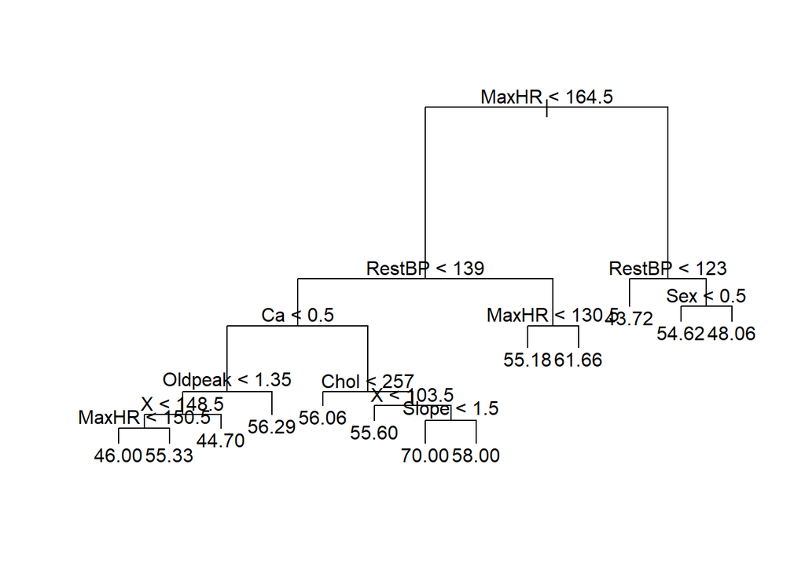

```r
plot(tree.heart)
text(tree.heart, pretty = 0)
```

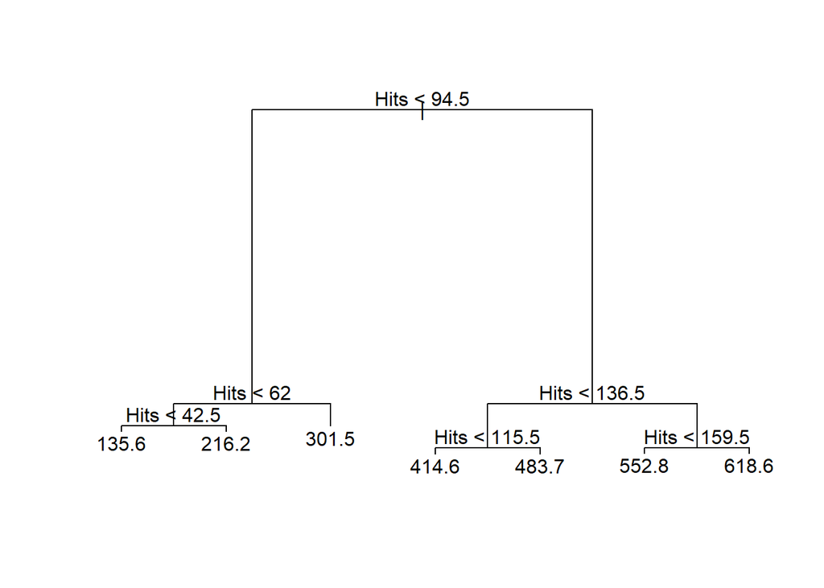

```r
plot(tree.hitters)
text(tree.hitters, pretty = 0)
```

It is worth noting that we could have fit a much bigger tree, by passing `control = tree.control(nobs = length(train), mindev = 0)` into the `tree()` function.

Now we use the `cv.tree()` function to see whether pruning the tree will improve performance.

```r
cv.heart <- cv.tree(tree.heart)
```

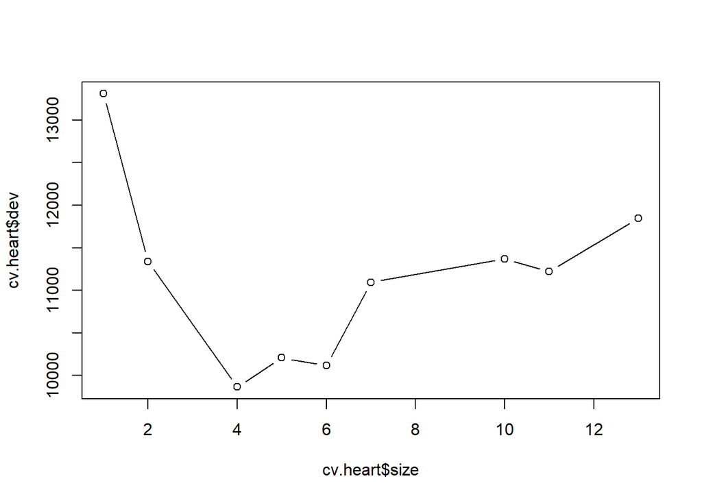

```r
plot(cv.heart$size, cv.heart$dev, type = "b")
```

```r
cv.hitters <- cv.tree(tree.hitters)
```

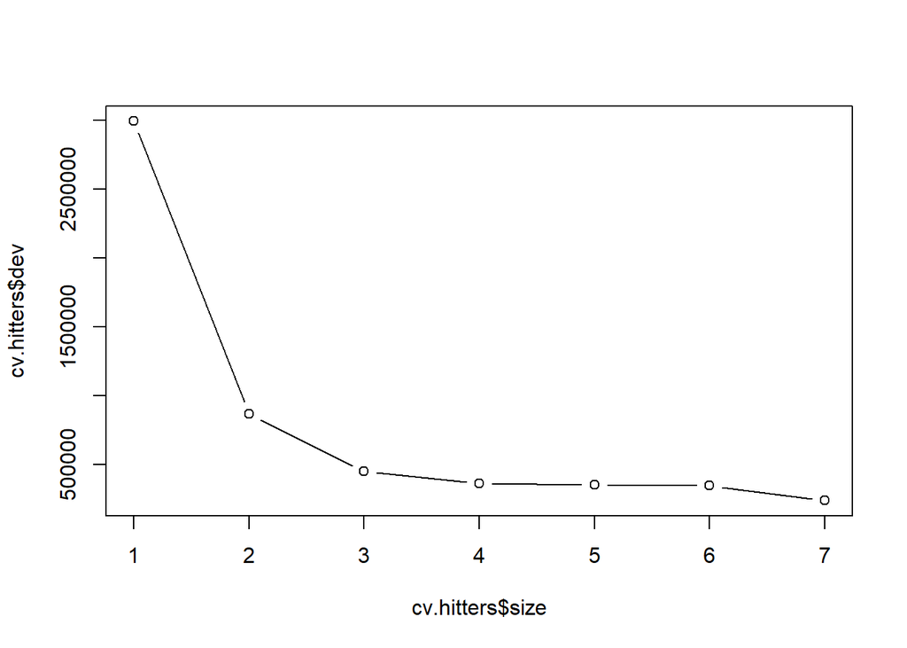

```r
plot(cv.hitters$size, cv.hitters$dev, type = "b")
```

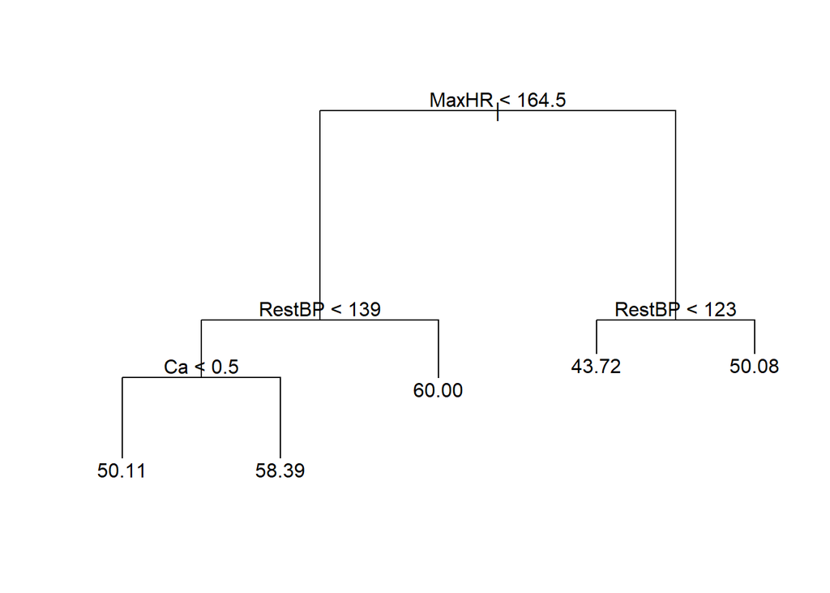

```r
prune.heart <- prune.tree(tree.heart, best = 5)
plot(prune.heart)
text(prune.heart, pretty = 0)
```

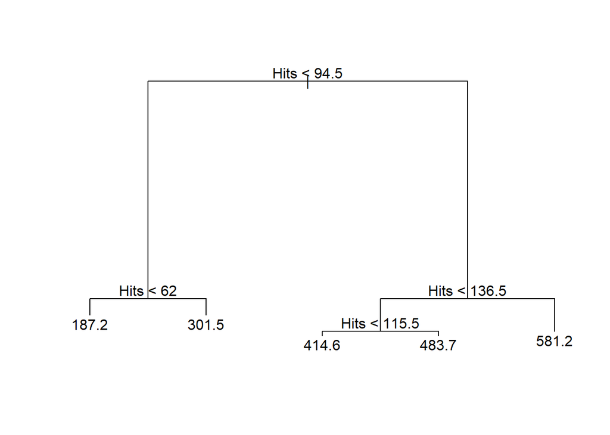

```r
prune.hitters <- prune.tree(tree.hitters, best = 5)
plot(prune.hitters)
text(prune.hitters, pretty = 0)
```

```r
yhat <- predict(tree.heart, newdata = Heart[-train_heart, ])
```

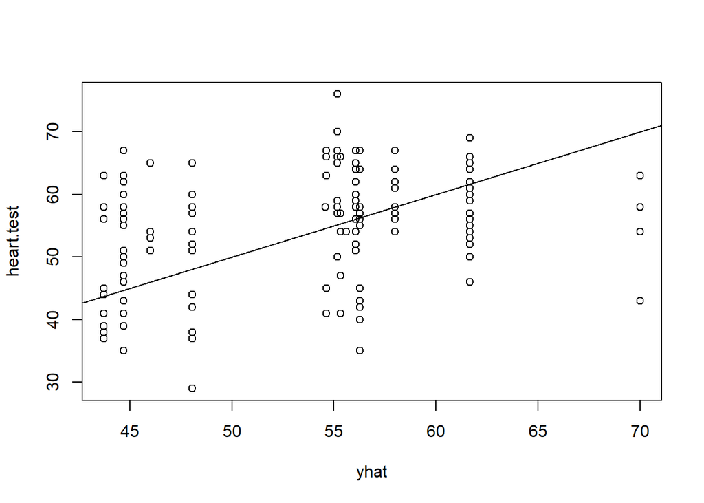

```r
heart.test <- Heart[-train_heart, "Age"]
plot(yhat, heart.test)
abline(0, 1)
```

```r
mean((yhat - heart.test)^2)
```

```
## [1] 81.55878
```

```r
yhat <- predict(tree.hitters, newdata = Hitters[-train_hitters, ])
```

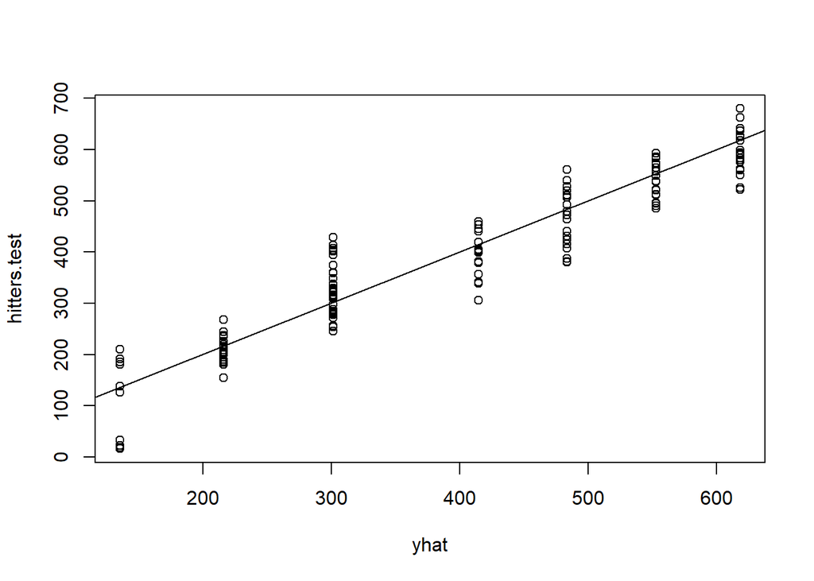

```r
hitters.test <- Hitters[-train_hitters, "AtBat"]
plot(yhat, hitters.test)
abline(0, 1)
```

```r
mean((yhat - hitters.test)^2)
```

```
## [1] 2384.466
```

## Bagging and Random Forests

```r
# Load libraries needed for Chapter 8 tree-based methods
library(ISLR2)        # provides the Hitters dataset
library(tree)         # for single regression/classification trees
library(randomForest) # for bagging and random forests
library(ggplot2)      # for plots
library(dplyr)        # for data cleaning and transformation
# Set a seed so results are reproducible
set.seed(123)
# Show code in report, hide package startup and warning messages
knitr::opts_chunk$set(echo = TRUE, message = FALSE, warning = FALSE)
```

# 8.3 Bagging and Random Forests

## 8.3.0 Data Check and Modeling Assumptions

Tree-based methods differ from the Chapter 3 and Chapter 7 models we studied earlier. Linear regression and logistic regression depend much more heavily on assumptions about functional form, and those methods often require more EDA to check linearity, variance patterns, and possible transformations. In contrast, tree-based methods partition the predictor space into regions and therefore do not require linearity, normality, or equal variance in the same way. For this reason, a full EDA section is not necessary here. Instead, the important checks are whether missing values are present, whether the response variable has the correct type, and whether categorical predictors are coded properly. This is consistent with the Chapter 8 framework, which emphasizes prediction through recursive partitioning and ensemble averaging rather than parametric assumptions.

For intuition, consider a situation in which salary increases quickly early in a career and then levels off. A linear model would need explicit nonlinear terms to capture that shape. A tree-based method can instead split the predictor space into career-stage intervals and assign different average predictions to each region. That is why tree-based methods usually need only a short data check rather than a full assumption-testing EDA section.

## A. Hitters dataset for Regression

### 8.3.1 Load and Prepare the Hitters Data

```r
# Load the Hitters dataset from ISLR2
data(Hitters)

# Inspect raw data - data types, missing values
summary(Hitters)
```

```
##      AtBat            Hits         HmRun            Runs
##  Min.   : 16.0   Min.   :  1   Min.   : 0.00   Min.   :  0.00
##  1st Qu.:255.2   1st Qu.: 64   1st Qu.: 4.00   1st Qu.: 30.25
##  Median :379.5   Median : 96   Median : 8.00   Median : 48.00
##  Mean   :380.9   Mean   :101   Mean   :10.77   Mean   : 50.91
##  3rd Qu.:512.0   3rd Qu.:137   3rd Qu.:16.00   3rd Qu.: 69.00
##  Max.   :687.0   Max.   :238   Max.   :40.00   Max.   :130.00
##
##       RBI             Walks            Years            CAtBat
##  Min.   :  0.00   Min.   :  0.00   Min.   : 1.000   Min.   :   19.0
##  1st Qu.: 28.00   1st Qu.: 22.00   1st Qu.: 4.000   1st Qu.:  816.8
##  Median : 44.00   Median : 35.00   Median : 6.000   Median : 1928.0
##  Mean   : 48.03   Mean   : 38.74   Mean   : 7.444   Mean   : 2648.7
##  3rd Qu.: 64.75   3rd Qu.: 53.00   3rd Qu.:11.000   3rd Qu.: 3924.2
##  Max.   :121.00   Max.   :105.00   Max.   :24.000   Max.   :14053.0
##
##      CHits            CHmRun           CRuns             CRBI
##  Min.   :   4.0   Min.   :  0.00   Min.   :   1.0   Min.   :   0.00
##  1st Qu.: 209.0   1st Qu.: 14.00   1st Qu.: 100.2   1st Qu.:  88.75
##  Median : 508.0   Median : 37.50   Median : 247.0   Median : 220.50
##  Mean   : 717.6   Mean   : 69.49   Mean   : 358.8   Mean   : 330.12
##  3rd Qu.:1059.2   3rd Qu.: 90.00   3rd Qu.: 526.2   3rd Qu.: 426.25
##  Max.   :4256.0   Max.   :548.00   Max.   :2165.0   Max.   :1659.00
##
##      CWalks        League  Division    PutOuts          Assists
##  Min.   :   0.00   A:175   E:157    Min.   :   0.0   Min.   :  0.0
##  1st Qu.:  67.25   N:147   W:165    1st Qu.: 109.2   1st Qu.:  7.0
##  Median : 170.50                    Median : 212.0   Median : 39.5
##  Mean   : 260.24                    Mean   : 288.9   Mean   :106.9
##  3rd Qu.: 339.25                    3rd Qu.: 325.0   3rd Qu.:166.0
##  Max.   :1566.00                    Max.   :1378.0   Max.   :492.0
##
##      Errors          Salary       NewLeague
##  Min.   : 0.00   Min.   :  67.5   A:176
##  1st Qu.: 3.00   1st Qu.: 190.0   N:146
##  Median : 6.00   Median : 425.0
##  Mean   : 8.04   Mean   : 535.9
##  3rd Qu.:11.00   3rd Qu.: 750.0
##  Max.   :32.00   Max.   :2460.0
##                  NA's   :59
```

```r
# Prepare data
hitters <- Hitters %>%
  na.omit() %>%
  mutate(logSalary = log(Salary))
# See number of variables
ncol(hitters)
```

```
## [1] 21
```

```r
# Number of complete observations after cleaning
n <- nrow(hitters)

# Create a 70/30 train-test split
train_idx <- sample(1:n, size = floor(0.7 * n))
hitters_train <- hitters[train_idx, ]
hitters_test  <- hitters[-train_idx, ]

# Count the number of predictors used in the bagging/RF model
p_hitters <- ncol(hitters_train) - 2 # Subtract 2 because Salary (response) and logSalary (stable version of the same response) are not predictors
p_hitters
```

```
## [1] 19
```

We use `na.omit()` because `randomForest()` does not handle missing values directly. If observations with missing predictor or response values are kept, the model fitting process can fail or produce inconsistent splits across trees. We define `logSalary = log(Salary)` because log transformation reduces skewness and stabilizes the spread of the response. This also matches the Chapter 8 lab setup for tree-based regression. Finally, we use a train-test split so that model performance is evaluated on test data rather than only on the training sample.

### 8.3.2 Why Bagging Uses `mtry = p`

Bagging is the special case of random forests in which **all predictors are considered at every split**. In `randomForest()`, this means setting `mtry = p`, where `p` is the total number of predictors. Random forests only use a smaller `mtry`, which reduces correlation among trees and often improves prediction.

### 8.3.3 Single Regression Tree Baseline

```r
# Fit a single regression tree as the baseline model
# We predict logSalary and remove Salary from the predictor set
hitters_tree <- tree(logSalary ~ . - Salary, data = hitters_train)

# Model summary
summary(hitters_tree)
```

```
##
## Regression tree:
## tree(formula = logSalary ~ . - Salary, data = hitters_train)
## Variables actually used in tree construction:
## [1] "CAtBat" "CRuns"  "AtBat"  "Walks"  "CRBI"   "Runs"
## Number of terminal nodes:  9
## Residual mean deviance:  0.181 = 31.67 / 175
## Distribution of residuals:
##     Min.  1st Qu.   Median     Mean  3rd Qu.     Max.
## -1.42700 -0.21510  0.03423  0.00000  0.23450  2.15600
```

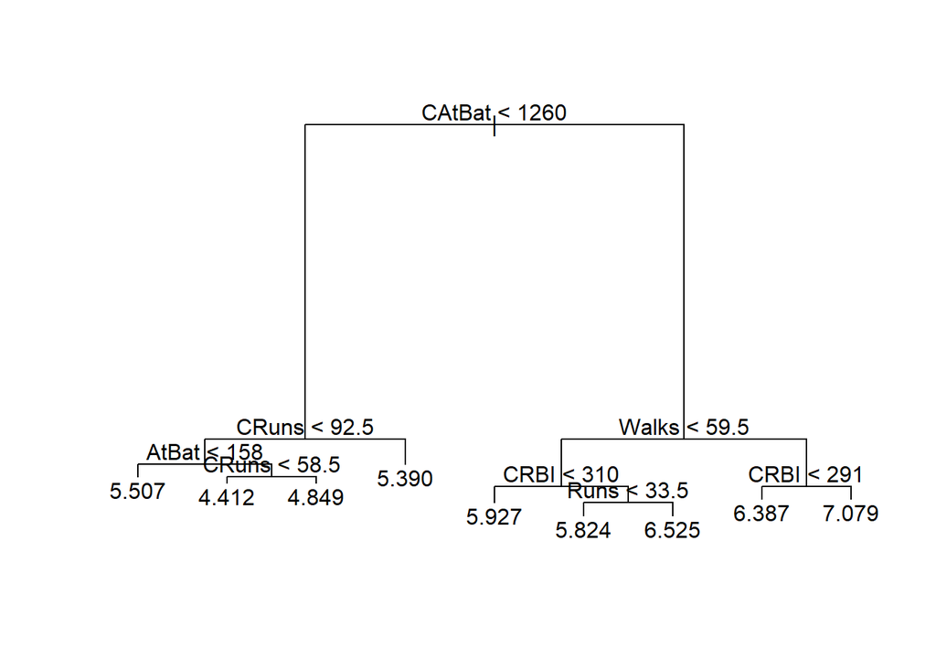

```r
# Plot the fitted tree
plot(hitters_tree)
# Add split labels and terminal node predictions to the tree plot
text(hitters_tree, pretty = 0)
```

```r
# Predict on the test set
hitters_tree_pred <- predict(hitters_tree, newdata = hitters_test)

# Compute test MSE for the single tree
hitters_tree_mse <- mean((hitters_test$logSalary - hitters_tree_pred)^2)
hitters_tree_mse
```

```
## [1] 0.2306723
```

We use the single tree as our baseline model because it is easy to visualize and interpret. The tree selects variables such as `CAtBat`, `CRuns`, `AtBat`, `Walks`, `CRBI`, and `Runs`, indicating that both accumulated career performance and current-season performance contribute to salary prediction. However, a single tree is a **high-variance** learner: small changes in the training data can lead to different splits, different tree shapes, and noticeably different predictions. Its test MSE of 0.2307 therefore provides a useful benchmark for comparison with bagging and random forest.

### 8.3.4 Bagging for Hitters

```r
# Fit a bagging model using randomForest()
set.seed(1234)
hitters_bag <- randomForest(
  logSalary ~ . - Salary,
  data = hitters_train,
  mtry = p_hitters,
  ntree = 500,
  importance = TRUE
)

# Show model information, including OOB statistics
hitters_bag
```

```
##
## Call:
##  randomForest(formula = logSalary ~ . - Salary, data = hitters_train,      mtry = p_hitters, ntree = 500, importance = TRUE)
##                Type of random forest: regression
##                      Number of trees: 500
## No. of variables tried at each split: 19
##
##           Mean of squared residuals: 0.244076
##                     % Var explained: 70.66
```

```r
# Predict on the test set
hitters_bag_pred <- predict(hitters_bag, newdata = hitters_test)

# Compute test MSE
hitters_bag_mse <- mean((hitters_test$logSalary - hitters_bag_pred)^2)
hitters_bag_mse
```

```
## [1] 0.1970036
```

In bagging, all predictors are considered at every split, so `mtry = p` reproduces the bagging procedure. With 500 trees, the bagged model reduces the test MSE to 0.1970, improving over the single tree. This is consistent with Chapter 8: averaging many high-variance trees reduces variance and usually improves predictive stability. Although 500 trees is a common practical default because large forests tend to stabilize prediction error, our additional `ntree` analysis shows that the lowest observed test MSE in the tested grid occurs at 30 trees (0.1903), while larger forests such as 500 and 800 trees produce very similar but not strictly better results in this result.

```r
set.seed(1234)
ntree_candidates_hitters <- c(10, 30, 50, 100, 150, 200, 300, 500, 800)

hitters_bag_ntree_results <- data.frame(
  ntree = integer(),
  test_mse = numeric(),
  oob_mse = numeric()
)

for (nt in ntree_candidates_hitters) {

  bag_model <- randomForest(
    logSalary ~ . - Salary,
    data = hitters_train,
    mtry = p_hitters,   # bagging
    ntree = nt,
    importance = FALSE
  )

  pred <- predict(bag_model, newdata = hitters_test)
  test_mse <- mean((hitters_test$logSalary - pred)^2)
  oob_mse <- tail(bag_model$mse, 1)

  hitters_bag_ntree_results <- rbind(
    hitters_bag_ntree_results,
    data.frame(
      ntree = nt,
      test_mse = test_mse,
      oob_mse = oob_mse
    )
  )
}

hitters_bag_ntree_results
```

```
##   ntree  test_mse   oob_mse
## 1    10 0.2498937 0.3029960
## 2    30 0.1902549 0.2807720
## 3    50 0.2084126 0.2426014
## 4   100 0.1943536 0.2488999
## 5   150 0.1989334 0.2463964
## 6   200 0.1961365 0.2403213
## 7   300 0.2013772 0.2442765
## 8   500 0.2000848 0.2442750
## 9   800 0.1927316 0.2433436
```

The `ntree` sensitivity analysis shows that bagging performance improves quickly once the ensemble contains more than a very small number of trees. In our tested grid, the lowest test MSE is 0.1903 at 30 trees, while the OOB MSE stabilizes around 200 trees and beyond. This suggests that the bagged ensemble becomes stable relatively early in this dataset. We still keep 500 trees as a reasonable reporting value because it is a standard large-forest setting and produces stable performance, but the results show that bagging did not require an extremely large ensemble to become effective here.

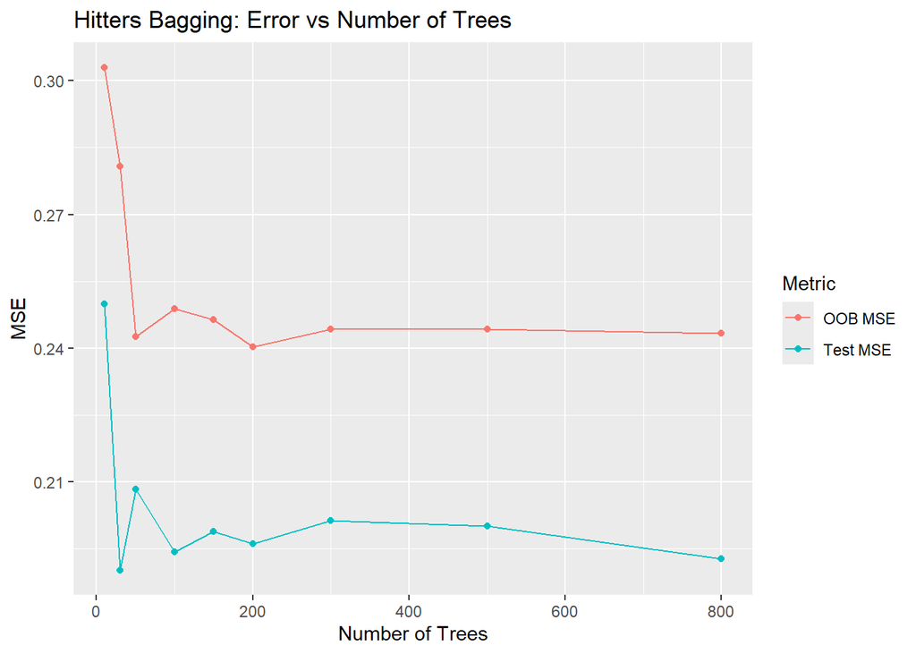

```r
set.seed(1234)
hitters_bag_ntree_long <- rbind(
  data.frame(
    ntree = hitters_bag_ntree_results$ntree,
    error = hitters_bag_ntree_results$test_mse,
    metric = "Test MSE"
  ),
  data.frame(
    ntree = hitters_bag_ntree_results$ntree,
    error = hitters_bag_ntree_results$oob_mse,
    metric = "OOB MSE"
  )
)

ggplot(hitters_bag_ntree_long, aes(x = ntree, y = error, color = metric)) +
  geom_line() +
  geom_point() +
  labs(
    title = "Hitters Bagging: Error vs Number of Trees",
    x = "Number of Trees",
    y = "MSE",
    color = "Metric"
  )
```

### 8.3.5 Random Forest `mtry` Tuning Loop for Hitters

```r
# Using random forest method, we can evaluate all possible values for mtry to show how random forest performance changes. This lets us visualize the tradeoff between tree strength and tree correlation
set.seed(1234)

# Try every possible mtry from 1 up to p
mtry_grid_hitters <- 1:p_hitters

# Create an empty results data frame
hitters_rf_tuning <- data.frame(
  mtry = integer(), # Records all possible number of trees
  test_mse = numeric(), # Records prediction errors
  oob_mse = numeric() # Records out-of-bag (OOB) errors
)

# Create an empty list to store fitted models
hitters_rf_models <- list()

# Loop through all candidate mtry values
for (m in mtry_grid_hitters) {

  # Fit a random forest with the current mtry
  rf_model <- randomForest(
    logSalary ~ . - Salary,
    data = hitters_train,
    mtry = m,
    ntree = 500,
    importance = TRUE
  )

  # Predict on the test set
  pred <- predict(rf_model, newdata = hitters_test)

  # Compute test MSE
  test_mse <- mean((hitters_test$logSalary - pred)^2)

  # Extract the final OOB MSE from the fitted forest
  oob_mse <- tail(rf_model$mse, 1)

  # Store the results
  hitters_rf_tuning <- rbind(
    hitters_rf_tuning,
    data.frame(mtry = m, test_mse = test_mse, oob_mse = oob_mse)
  )

  # Save the model in case we want the best one later
  hitters_rf_models[[paste0("mtry_", m)]] <- rf_model
}
hitters_rf_tuning
```

```
##    mtry  test_mse   oob_mse
## 1     1 0.1835477 0.2518615
## 2     2 0.1555940 0.2295903
## 3     3 0.1579274 0.2270489
## 4     4 0.1641175 0.2316536
## 5     5 0.1669316 0.2262034
## 6     6 0.1757972 0.2332677
## 7     7 0.1832295 0.2308288
## 8     8 0.1931138 0.2357439
## 9     9 0.1781613 0.2330514
## 10   10 0.1914488 0.2356275
## 11   11 0.1863992 0.2361968
## 12   12 0.1911205 0.2384426
## 13   13 0.1911939 0.2375588
## 14   14 0.2037479 0.2420217
## 15   15 0.2000525 0.2408076
## 16   16 0.1951217 0.2445694
## 17   17 0.1892124 0.2415241
## 18   18 0.1997911 0.2397727
## 19   19 0.1962017 0.2450745
```

```r
# Identify the best mtry based on test MSE
best_mtry_hitters <- hitters_rf_tuning$mtry[which.min(hitters_rf_tuning$test_mse)]
best_rf_hitters <- hitters_rf_models[[paste0("mtry_", best_mtry_hitters)]]
best_mtry_hitters # Best mtry
```

```
## [1] 2
```

```r
min(hitters_rf_tuning$test_mse) # Best test MSE
```

```
## [1] 0.155594
```

For random forests, a common default in regression is to use approximately p/3 predictors at each split. With p=19, that rule would suggest an `mtry` near 6. However, rather than relying only on the default, we test all possible `mtry` values so that the performance pattern is explicit. The results show that the best test MSE is 0.1556 at `mtry = 2`, which is substantially better than bagging at `mtry = 19`. This indicates that in the Hitters dataset, reducing the number of predictors considered at each split greatly lowers tree correlation and improves ensemble prediction.

### 8.3.6 Plot: Hitters Test MSE vs `mtry`

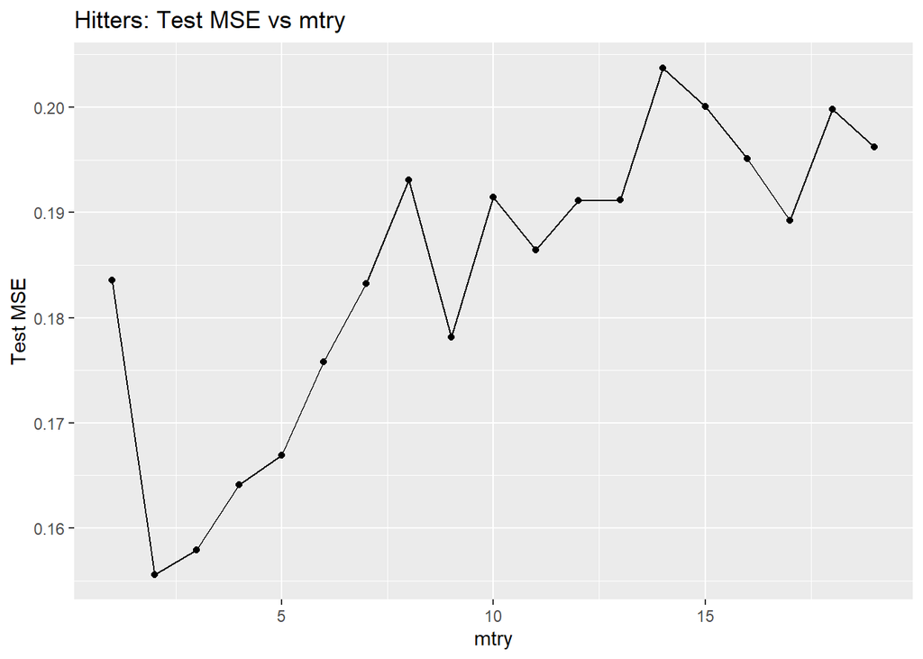

```r
# Plot test MSE against mtry
ggplot(hitters_rf_tuning, aes(x = mtry, y = test_mse)) +
  geom_line() +
  geom_point() +
  labs(
    title = "Hitters: Test MSE vs mtry",
    x = "mtry",
    y = "Test MSE"
  )
```

The plot shows a clear minimum near `mtry = 2`. As `mtry` increases toward the bagging case, the test MSE rises, suggesting that trees become too similar when all predictors are always available. Thus, the random forest improves on bagging by balancing tree strength and tree diversity more effectively.

### 8.3.7 Variable Importance for Hitters

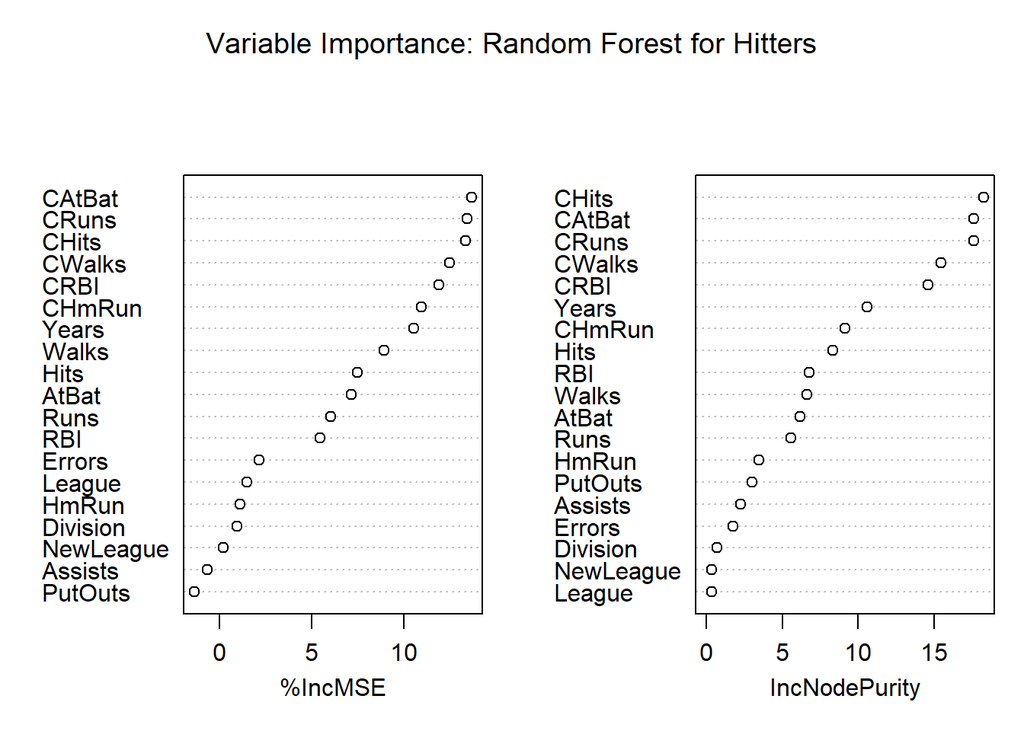

```r
# Plot variable importance for the best random forest model
varImpPlot(best_rf_hitters, main = "Variable Importance: Random Forest for Hitters")
```

The variable importance plot reports two measures. `%IncMSE` measures how much prediction error increases when a variable is permuted, so larger values indicate that the model depends more strongly on that variable for accurate prediction. `IncNodePurity` measures the total reduction in node impurity contributed by that variable across the forest. In regression, node impurity is measured through reductions in residual sum of squares (RSS), so variables with larger `IncNodePurity` values are those that frequently create strong splits. In our results, the most important variables are `CAtBat`, `CRuns`, `CHits`, `CWalks`, and `CRBI`. These are cumulative career statistics, which makes substantive sense because long-term performance should be strongly related to salary.

### 8.3.8 Hitters Model Comparison

```r
# Create a comparison table for the three main models
hitters_model_comparison <- data.frame(
  Model = c(
    "Single Tree",
    "Bagging (mtry = p)",
    paste0("Random Forest (best mtry = ", best_mtry_hitters, ")")
  ),
  Test_MSE = c(
    hitters_tree_mse,
    hitters_bag_mse,
    min(hitters_rf_tuning$test_mse)
  )
)
hitters_model_comparison
```

```
##                           Model  Test_MSE
## 1                   Single Tree 0.2306723
## 2            Bagging (mtry = p) 0.1970036
## 3 Random Forest (best mtry = 2) 0.1555940
```

The model comparison shows a clear improvement across the ensemble workflow. The single tree yields a test MSE of 0.2307, bagging reduces this to 0.1970, and the best random forest further reduces it to 0.1556. This pattern strongly supports the Chapter 8 argument that single trees have high variance, bagging reduces variance by averaging, and random forests can improve further by reducing correlation among trees.

## B. Heart — Classification

### 8.3.9 Load and Prepare the Heart Data

```r
# Read the Heart dataset from CSV
# Replace "Heart.csv" with your exact file name if needed
heart <- read.csv("Heart.csv", stringsAsFactors = TRUE)

# Remove rows with missing values and row index X
heart <- na.omit(heart) %>% select(-X)
# Check missing values
colSums(is.na(heart))
```

```
##       Age       Sex ChestPain    RestBP      Chol       Fbs   RestECG     MaxHR
##         0         0         0         0         0         0         0         0
##     ExAng   Oldpeak     Slope        Ca      Thal       AHD
##         0         0         0         0         0         0
```

```r
# Make sure the response is a factor for classification
heart$AHD <- as.factor(heart$AHD)

# Check structure
str(heart)
```

```
## 'data.frame':    297 obs. of  14 variables:
##  $ Age      : int  63 67 67 37 41 56 62 57 63 53 ...
##  $ Sex      : int  1 1 1 1 0 1 0 0 1 1 ...
##  $ ChestPain: Factor w/ 4 levels "asymptomatic",..: 4 1 1 2 3 3 1 1 1 1 ...
##  $ RestBP   : int  145 160 120 130 130 120 140 120 130 140 ...
##  $ Chol     : int  233 286 229 250 204 236 268 354 254 203 ...
##  $ Fbs      : int  1 0 0 0 0 0 0 0 0 1 ...
##  $ RestECG  : int  2 2 2 0 2 0 2 0 2 2 ...
##  $ MaxHR    : int  150 108 129 187 172 178 160 163 147 155 ...
##  $ ExAng    : int  0 1 1 0 0 0 0 1 0 1 ...
##  $ Oldpeak  : num  2.3 1.5 2.6 3.5 1.4 0.8 3.6 0.6 1.4 3.1 ...
##  $ Slope    : int  3 2 2 3 1 1 3 1 2 3 ...
##  $ Ca       : int  0 3 2 0 0 0 2 0 1 0 ...
##  $ Thal     : Factor w/ 3 levels "fixed","normal",..: 1 2 3 2 2 2 2 2 3 3 ...
##  $ AHD      : Factor w/ 2 levels "No","Yes": 1 2 2 1 1 1 2 1 2 2 ...
##  - attr(*, "na.action")= 'omit' Named int [1:6] 88 167 193 267 288 303
##   ..- attr(*, "names")= chr [1:6] "88" "167" "193" "267" ...
```

```r
# Create a 70/30 train-test split
set.seed(1234)
n_heart <- nrow(heart)
train_idx_heart <- sample(1:n_heart, size = floor(0.7 * n_heart))
heart_train <- heart[train_idx_heart, ]
heart_test  <- heart[-train_idx_heart, ]

# Number of predictors
p_heart <- ncol(heart_train) - 1
p_heart
```

```
## [1] 13
```

For classification, the key setup step is ensuring that the response variable is coded as a factor. This tells `randomForest()` to perform classification rather than regression. We also remove the row index column `X`, since it is not a meaningful predictor and should not influence the model. As in the Hitters analysis, we keep the data check brief because tree based methods do not require the same kind of full parametric assumption EDA used for linear or logistic models.

### 8.3.10 Single Classification Tree Base Model

```r
# Fit a single classification tree
heart_tree <- tree(AHD ~ ., data = heart_train)
summary(heart_tree)
```

```
##
## Classification tree:
## tree(formula = AHD ~ ., data = heart_train)
## Variables actually used in tree construction:
## [1] "Thal"      "Ca"        "MaxHR"     "RestBP"    "Sex"       "Age"
## [7] "ChestPain" "Chol"      "Oldpeak"
## Number of terminal nodes:  19
## Residual mean deviance:  0.383 = 72 / 188
## Misclassification error rate: 0.09179 = 19 / 207
```

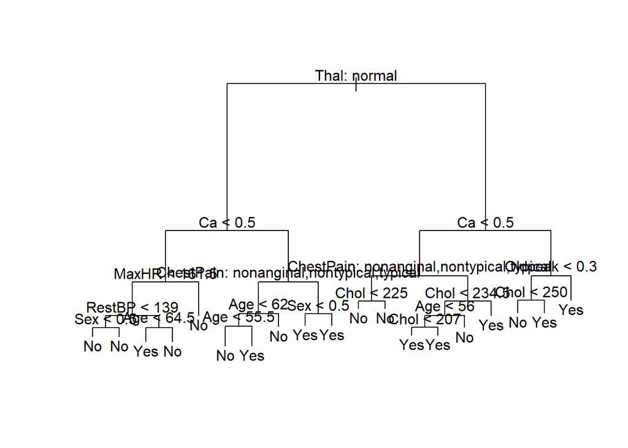

```r
plot(heart_tree)
text(heart_tree, pretty = 0)
```

```r
# Predict class labels on the test set
heart_tree_pred <- predict(heart_tree, newdata = heart_test, type = "class")

# Confusion matrix
heart_tree_tab <- table(Predicted = heart_tree_pred, Actual = heart_test$AHD)
heart_tree_tab
```

```
##          Actual
## Predicted No Yes
##       No  43  12
##       Yes  5  30
```

```r
# Test classification error
heart_tree_err <- mean(heart_tree_pred != heart_test$AHD)
heart_tree_err
```

```
## [1] 0.1888889
```

The single classification tree serves as an base model for interpretation. It selects variables such as `Thal`, `Ca`, `MaxHR`, `RestBP`, `Sex`, `Age`, `ChestPain`, `Chol`, and `Oldpeak`, all of which are clinically plausible predictors of heart disease. Its test error is 0.1889. Like regression trees, classification trees are **high variance learners** because a small change in the training sample can produce different splits and a different decision structure. This instability motivates the use of ensemble methods.

### 8.3.11 Bagging for Heart

```r
# Bagging for classification:
set.seed(1234)
heart_bag <- randomForest(
  AHD ~ .,
  data = heart_train,
  mtry = p_heart,
  ntree = 500,
  importance = TRUE
)
heart_bag
```

```
##
## Call:
##  randomForest(formula = AHD ~ ., data = heart_train, mtry = p_heart,      ntree = 500, importance = TRUE)
##                Type of random forest: classification
##                      Number of trees: 500
## No. of variables tried at each split: 13
##
##         OOB estimate of  error rate: 17.87%
## Confusion matrix:
##     No Yes class.error
## No  96  16   0.1428571
## Yes 21  74   0.2210526
```

```r
# Show model summary, including OOB error
summary(heart_bag)
```

```
##                 Length Class  Mode
## call               6   -none- call
## type               1   -none- character
## predicted        207   factor numeric
## err.rate        1500   -none- numeric
## confusion          6   -none- numeric
## votes            414   matrix numeric
## oob.times        207   -none- numeric
## classes            2   -none- character
## importance        52   -none- numeric
## importanceSD      39   -none- numeric
## localImportance    0   -none- NULL
## proximity          0   -none- NULL
## ntree              1   -none- numeric
## mtry               1   -none- numeric
## forest            14   -none- list
## y                207   factor numeric
## test               0   -none- NULL
## inbag              0   -none- NULL
## terms              3   terms  call
```

```r
# Predict classes on the test set
heart_bag_pred <- predict(heart_bag, newdata = heart_test, type = "class")

# Confusion matrix
heart_bag_tab <- table(Predicted = heart_bag_pred, Actual = heart_test$AHD)
heart_bag_tab
```

```
##          Actual
## Predicted No Yes
##       No  40  12
##       Yes  8  30
```

```r
# Test classification error
heart_bag_err <- mean(heart_bag_pred != heart_test$AHD)
heart_bag_err
```

```
## [1] 0.2222222
```

In classification, bagging combines trees through majority vote. The out-of-bag (OOB) error provides an internal estimate of prediction error because each tree leaves part of the bootstrap sample unused, and those left-out observations can serve as validation cases for that tree. In our run, the bagged model has a test error of 0.2222, which is actually slightly worse than the single tree. Although bagging often improves unstable learners on average, this result shows that improvement is not guaranteed in every train-test split. It is therefore useful to compare bagging directly with random forest rather than assume monotonic improvement.

### 8.3.12 Random Forest `mtry` Tuning Loop for Heart

```r
# Tune mtry for Heart classification
set.seed(1234)

# Try every possible mtry from 1 up to p
mtry_grid_heart <- 1:p_heart

# Empty results data frame
heart_rf_tuning <- data.frame(
  mtry = integer(),
  test_error = numeric(),
  oob_error = numeric()
)

# Empty list to store models
heart_rf_models <- list()

# Loop through all candidate mtry values
for (m in mtry_grid_heart) {

  # Fit the random forest
  rf_model <- randomForest(
    AHD ~ .,
    data = heart_train,
    mtry = m,
    ntree = 500,
    importance = TRUE
  )

  # Predict class labels
  pred <- predict(rf_model, newdata = heart_test, type = "class")

  # Compute test error
  test_error <- mean(pred != heart_test$AHD)

  # Extract final OOB error
  oob_error <- tail(rf_model$err.rate[, "OOB"], 1)

  # Record results
  heart_rf_tuning <- rbind(
    heart_rf_tuning,
    data.frame(mtry = m, test_error = test_error, oob_error = oob_error)
  )

  # Save fitted model
  heart_rf_models[[paste0("mtry_", m)]] <- rf_model
}
heart_rf_tuning
```

```
##    mtry test_error oob_error
## 1     1  0.1777778 0.1545894
## 2     2  0.1777778 0.1787440
## 3     3  0.1777778 0.1594203
## 4     4  0.1888889 0.1642512
## 5     5  0.2000000 0.1690821
## 6     6  0.2000000 0.1739130
## 7     7  0.2111111 0.1835749
## 8     8  0.2222222 0.1835749
## 9     9  0.2222222 0.1884058
## 10   10  0.2111111 0.2028986
## 11   11  0.2111111 0.1884058
## 12   12  0.2111111 0.1739130
## 13   13  0.2111111 0.1739130
```

```r
# Best mtry based on test error
best_mtry_heart <- heart_rf_tuning$mtry[which.min(heart_rf_tuning$test_error)]
best_rf_heart <- heart_rf_models[[paste0("mtry_", best_mtry_heart)]]
best_mtry_heart # Best mtry
```

```
## [1] 1
```

```r
min(heart_rf_tuning$test_error) # Best test error
```

```
## [1] 0.1777778
```

In classification, a common default is to use approximately $\sqrt{p}$ predictors at each split. Since p=13 in the cleaned Heart dataset, that rule suggests an `mtry` near 3 or 4. However, we again test all possible values to make the performance pattern explicit. The lowest test error, 0.1778, is achieved at `mtry = 1`, and the same minimum also appears at `mtry = 2` and `mtry = 3`. As `mtry` increases, performance worse and approaches the bagging level. This pattern supports the random forest theory that smaller `mtry` values can improve prediction by reducing correlation among trees.

### 8.3.13 Plot: Heart Test Error vs `mtry`

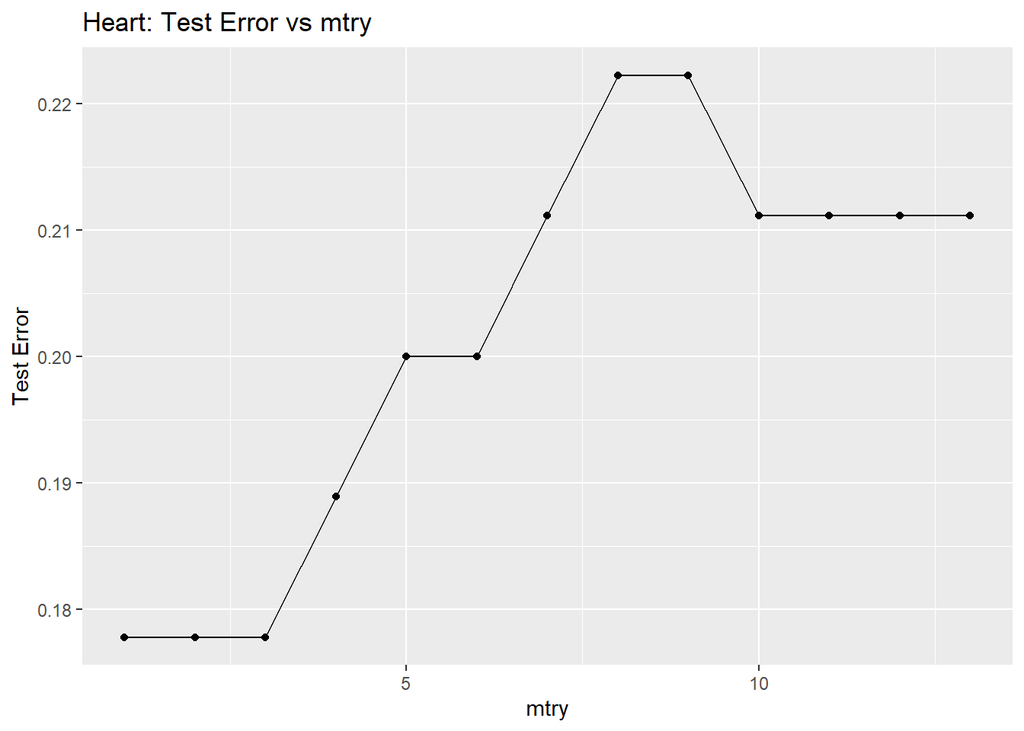

```r
# Plot Heart test error against mtry
ggplot(heart_rf_tuning, aes(x = mtry, y = test_error)) +
  geom_line() +
  geom_point() +
  labs(
    title = "Heart: Test Error vs mtry",
    x = "mtry",
    y = "Test Error"
  )
```

This plot shows how `mtry` values affect random forest classification performance and where the best predictive accuracy occurs.

### 8.3.14 Error vs Number of Trees for Heart

```r
# Evaluate how error changes as the number of trees increases
ntree_candidates <- c(10, 30, 50, 100, 150, 200, 300, 500, 800)

# Empty results table
heart_ntree_results <- data.frame(
  ntree = integer(),
  test_error = numeric(),
  oob_error = numeric()
)

# Use the best mtry found above and vary ntree
for (nt in ntree_candidates) {

  rf_model <- randomForest(
    AHD ~ .,
    data = heart_train,
    mtry = best_mtry_heart,
    ntree = nt,
    importance = FALSE
  )

  # Predict on test set
  pred <- predict(rf_model, newdata = heart_test, type = "class")

  # Compute test error
  test_err <- mean(pred != heart_test$AHD)

  # Final OOB error
  oob_err <- tail(rf_model$err.rate[, "OOB"], 1)

  # Store results
  heart_ntree_results <- rbind(
    heart_ntree_results,
    data.frame(ntree = nt, test_error = test_err, oob_error = oob_err)
  )
}
heart_ntree_results
```

```
##   ntree test_error oob_error
## 1    10  0.2222222 0.2378641
## 2    30  0.1555556 0.1690821
## 3    50  0.1777778 0.1835749
## 4   100  0.1888889 0.1642512
## 5   150  0.1555556 0.1690821
## 6   200  0.1666667 0.1690821
## 7   300  0.1666667 0.1449275
## 8   500  0.1888889 0.1690821
## 9   800  0.1777778 0.1449275
```

```r
# Best ntree value when using best mtry value
best_ntree_heart <- heart_ntree_results$ntree[which.min(heart_ntree_results$test_error)]
best_ntree_heart
```

```
## [1] 30
```

We next examine how the number of trees affects performance while holding `mtry` at its best tuned value. In our tested grid, the lowest test error of 0.1556 occurs at 30 trees and again at 150 trees, while the OOB error reaches its lowest level by 300 trees and remains low at 800 trees. This indicates that the ensemble becomes reasonably stable once the forest is moderately large, although the exact best test error in this run may occur at a smaller `ntree` because of sampling variability. Therefore, 500 trees remains a common practical default because it provides a sufficiently large and stable forest, even if a smaller value may produce the absolute minimum error in a particular train-test split.

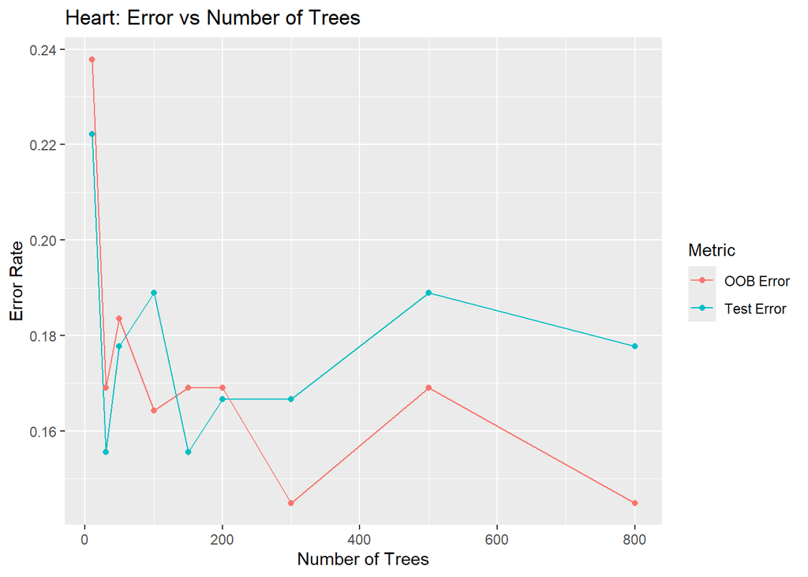

```r
# Reshape results for plotting
heart_ntree_long <- rbind(
  data.frame(
    ntree = heart_ntree_results$ntree,
    error = heart_ntree_results$test_error,
    type = "Test Error"
  ),
  data.frame(
    ntree = heart_ntree_results$ntree,
    error = heart_ntree_results$oob_error,
    type = "OOB Error"
  )
)

# Plot test and OOB error together
ggplot(heart_ntree_long, aes(x = ntree, y = error, color = type)) +
  geom_line() +
  geom_point() +
  labs(
    title = "Heart: Error vs Number of Trees",
    x = "Number of Trees",
    y = "Error Rate",
    color = "Metric"
  )
```

This plot is useful because it shows whether the ensemble stabilizes as more trees are added. In Chapter 8, ensemble methods typically improve and then level off as `ntree` becomes large. This also helps justify why `ntree = 500` is a reasonable default.

### 8.3.15 Variable Importance for Heart

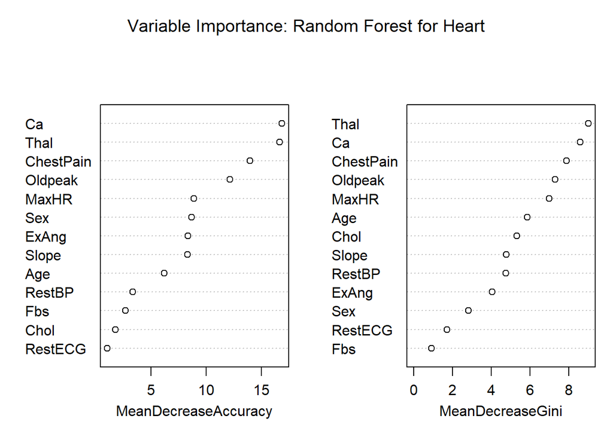

```r
# Plot variable importance for the best Heart RF model
varImpPlot(best_rf_heart, main = "Variable Importance: Random Forest for Heart")
```

For classification forests, the importance plot again reports two measures. `MeanDecreaseAccuracy` measures how much predictive accuracy falls when a variable is permuted, so larger values indicate stronger predictive importance. `MeanDecreaseGini` measures the total reduction in Gini impurity due to splits on that variable across the forest. **Gini impurity** reflects how mixed the classes are within a node; lower impurity means the node is more class-pure. Variables that strongly reduce Gini impurity therefore help separate the classes more effectively. In our results, the most important variables are `Ca`, `Thal`, `ChestPain`, `Oldpeak`, and `MaxHR`. These meaningful predictors supports the substantive validity of the model.

### 8.3.16 Heart Model Comparison

```r
# Compare single tree, bagging, and best random forest
heart_model_comparison <- data.frame(
  Model = c(
    "Single Tree",
    "Bagging (mtry = p)",
    paste0("Random Forest (best mtry = ", best_mtry_heart, ")")
  ),
  Test_Error = c(
    heart_tree_err,
    heart_bag_err,
    min(heart_rf_tuning$test_error)
  )
)
heart_model_comparison
```

```
##                           Model Test_Error
## 1                   Single Tree  0.1888889
## 2            Bagging (mtry = p)  0.2222222
## 3 Random Forest (best mtry = 1)  0.1777778
```

The model comparison shows that the best random forest provides the strongest predictive performance in this dataset. The single tree has a test error of 0.1889, bagging has a slightly worse error of 0.2222, and the best random forest reduces the error to 0.1778. Thus, while bagging does not improve the baseline in this particular run, random forest still delivers the best result by reducing correlation among trees through feature subsampling.

## 8.3.17 Bagging vs Random Forest: Theory and Concept Checklist

```
##                                             Item
## 1                                   Base learner
## 2                             Bootstrap sampling
## 3                      Trees built independently
## 4              Uses all predictors at each split
## 5 Uses random subset of predictors at each split
## 6                                      Main goal
## 7                           Relationship to mtry
## 8                                 Typical effect
##                                    Bagging
## 1                           Decision trees
## 2                                      Yes
## 3                                      Yes
## 4                                      Yes
## 5                                       No
## 6                          Reduce variance
## 7                                 mtry = p
## 8 Improves over a single tree by averaging
##                                         Random_Forest
## 1                                      Decision trees
## 2                                                 Yes
## 3                                                 Yes
## 4                                                  No
## 5                                                 Yes
## 6                    Reduce variance more effectively
## 7                                            mtry < p
## 8 Often improves over bagging by reducing correlation
```

Bagging and random forests are similar because both use bootstrap samples and average many trees. Their key difference is that random forests restrict the predictor set at each split. This makes trees less correlated, and that usually improves the ensemble’s performance.

## 8.3.18 Practice Checklist Using Our Two Datasets

[output not shown]

Using our two datasets as practice examples, for **Hitters** dataset, RF clearly improves over bagging by reducing tree correlation; for **Heart** dataset,RF improves over both bagging and the single tree, even though bagging alone does not improve the baseline. This indicates that the size of the improvement can differ by problem type and dataset structure.

## 8.3.19 Overall Model Improvement Across the Ensemble Workflow

```r
overall_summary <- list(
  Hitters = hitters_model_comparison,
  Heart = heart_model_comparison
)
overall_summary
```

```
## $Hitters
##                           Model  Test_MSE
## 1                   Single Tree 0.2306723
## 2            Bagging (mtry = p) 0.1970036
## 3 Random Forest (best mtry = 2) 0.1555940
##
## $Heart
##                           Model Test_Error
## 1                   Single Tree  0.1888889
## 2            Bagging (mtry = p)  0.2222222
## 3 Random Forest (best mtry = 1)  0.1777778
```

This final summary should make the model progression very clear: the overall results show that random forest performs best in both datasets, but the bagging step behaves differently across the two problems. In **Hitters**, prediction improves monotonically from single tree to bagging to random forest. In **Heart**, bagging performs slightly worse than the single tree, but random forest still achieves the lowest test error. This indicates that the main practical lesson of Chapter 8 is not that every ensemble step must always improve, but rather that random forests often outperform single trees and bagging because they combine variance reduction with tree decorrelation.

## 8.3.20 Concluding Discussion

Across both datasets, random forests produce the best predictive performance among the models considered. In the regression setting, the test MSE drops from 0.2307 for the single tree to 0.1970 for bagging and then to 0.1556 for the best random forest. In the classification setting, the single tree yields a test error of 0.1889, bagging gives 0.2222, and the best random forest reduces the error to 0.1778. These results illustrate the central Chapter 8 ideas: single trees are unstable and high-variance, bagging reduces variance by averaging many trees, and random forests often improve further by reducing correlation among trees through feature subsampling. The `mtry` tuning plots, `ntree` sensitivity analyses, and variable-importance plots make these theoretical ideas visible in practice.

## Bayesian Additive Regression Trees